# sclafani_dani_a4_task2

#### Data Preparation

```r
fish_data <- read_csv(here("data", "fish_catch.csv"))

fish <- fish_data %>%
  slice(5:67) %>%
  rename(year = "World Wild Fish Catch and Farmed Fish Production, 1950-2012",
         wild_catch = X2,
         farmed_fish = X3,
         total_production = X4) %>%
  mutate(year = as.numeric(year)) %>%
  mutate(total_production = as.numeric(total_production)) %>%
  mutate(wild_catch = as.numeric(wild_catch)) %>%
 mutate(farmed_fish = as.numeric(farmed_fish))
```

#### Setting up for Nonlinear least squares, need to add a column for time that makes 1950 = 0, and every year after that equal the corresponding number

```r
#creating a vector for the numbers 0-62
vec_1 <- 0:62

#making this vector a dataframe
df_vec <- vec_1 %>% as.data.frame()

#adding this vector as a column to the fish data frame
fish["time"] <- df_vec
```

#### Data Visualizations, Wild Fish Caught over time

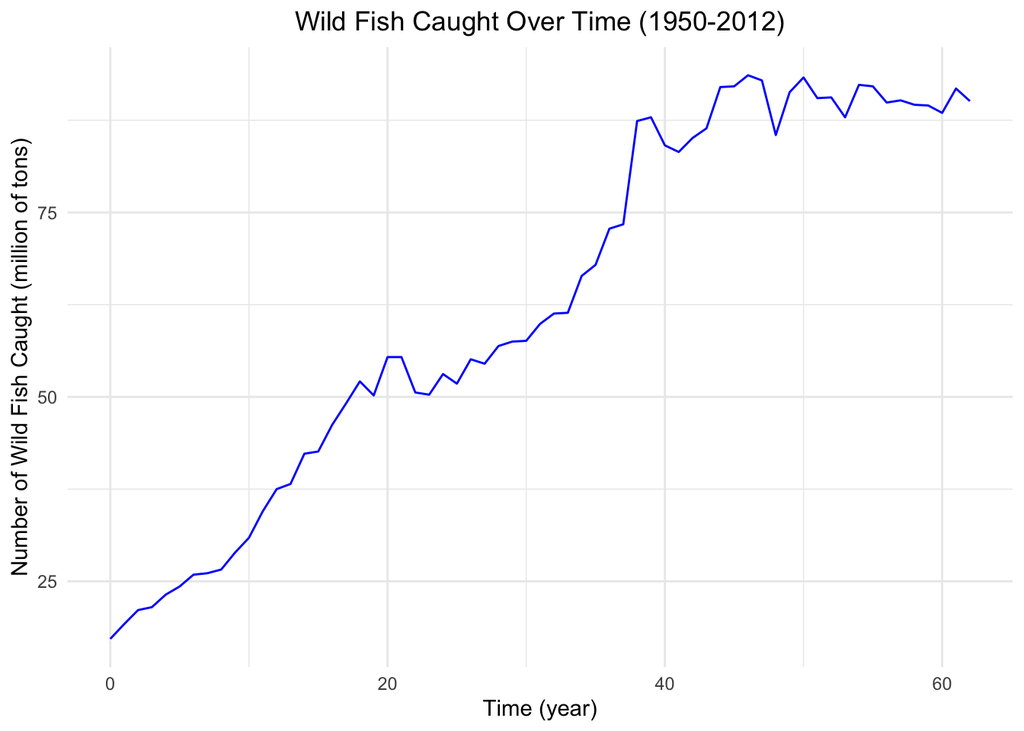

**Figure 1.0:** Wild Fish Caught over time from the year 1950 through 2012 globally

```r
ggplot(data = fish, aes(x = time, y = wild_catch)) + geom_line(color = "blue") +
  theme_minimal() +
  labs(x = "Time (year)", y = "Number of Wild Fish Caught (million of tons)", title = "Wild Fish Caught Over Time (1950-2012)")+
  theme(plot.title = element_text(hjust = 0.5))
```

The curve of wild fish caught over time appears to follow a logistic growth model, and can be described by the following function: $P(t)=\frac{K}{1+Ae^{-kt}}$. The parameters can be defined as, $K$ the carrying capacity, $A$ is the ratio $\frac{K-P_0}{P_0}$, and $k$ is the growth rate constant. The parameters $K$ and $A$ can be estimated as 89 million tons of wild fish and 3.94 million tons of wild fish using Figure 1.0. The growth rate constant, $k$ must be estimated using an exponential expression which is shown in the code below. $k$ is estimated to be 0.04.

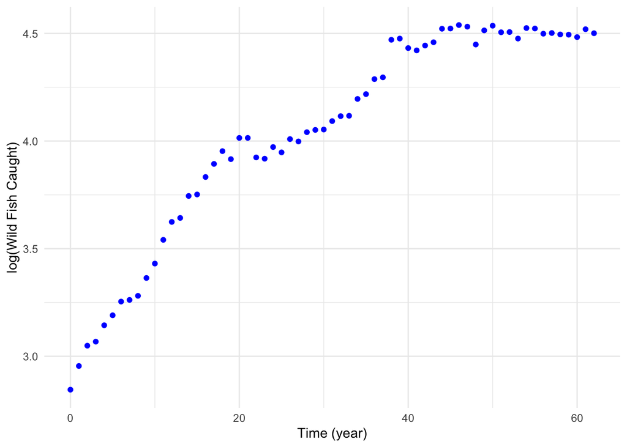

**Figure 2.0:** The log(wild fish caught(million of tons)) over time, from 1950-2012. Graph is used to estimate the time period at which the logistic growth curve appears to follow linear growth, which is needed to estimate $k$

```r
ggplot(data = fish, aes(x = time, y = log(wild_catch))) + geom_point(color = "blue")+
  theme_minimal()+
labs(x = "Time (year)", y = "log(Wild Fish Caught)")
```

#### Finding the *k* estimate during exponential phase

```r
#exponential only up to about time = 40. Need to log transform the population of wild fish caught. doing this so we can estimate *k*, the logistic growth constant

fish_exp <- fish %>%
  filter(time <40) %>%
  mutate(wild_catch = log(wild_catch))


fish_exp_lm <- lm(wild_catch ~ time, data = fish_exp)
#fish_exp_lm
```

#### Finding parameters using Nonlinear Least Squares

```r
fish_nls <- nls(wild_catch ~ K/(1 + A*exp(-r*time)),
              data = fish,
              start = list(K= 89, A =3.94, r = 0.04),
              trace = TRUE)
```

```
## 35329.16 :  89.00  3.94  0.04
## 28256.8 :  65.80364640  2.64442691  0.06389281
## 1402.015 :  101.05133462   4.46065615   0.06868314
## 1365.303 :  100.07121353   4.32101578   0.07015672
## 1365.146 :  100.30184670   4.31483831   0.06984088
## 1365.143 :  100.27441234   4.31654335   0.06989404
## 1365.143 :  100.27903628   4.31629395   0.06988563
## 1365.143 :  100.27830390   4.31633449   0.06988698
```

```r
#summary(fish_nls)
```

#### Making a Table with Model Outputs

```r
#using broom to clean up the model outputs into a table
model_output <- broom::tidy(fish_nls)
#model_output
```

Using NLS the model with estimated parameters the function is:
$$P(t) = \frac{100.3}{1+4.32e^{-0.07t}}$$
. The estimated parameters are also listed in Table 1.0 below.

```r
model_output %>% select(term, estimate) %>%
  gt %>%
  tab_header(
    title = "Parameter Estimates for Wild Fish Caught over time",
  ) %>%
  tab_footnote(
    footnote = "Results of Nonlinear Least Squares Model",
    locations = cells_title()
  ) %>%
  fmt_number(
    columns = vars(estimate),
    decimals = 2
  ) %>%
  tab_options(
    table.width = pct(40)
  ) %>%
  cols_label(
    term = "Parameter",
    estimate = "Estimated Value (million tons)"
  )
```

Parameter Estimates for Wild Fish Caught over time<sup>1</sup>

| Parameter | Estimated Value (million tons) |
| --- | --- |
| K | 100.28 |
| A | 4.32 |
| r | 0.07 |

<sup>*1*</sup> Results of Nonlinear Least Squares Model

**Table 1.0:** parameter estimate results of the nonlinear least squares model of wild fish caught over time from 1950-2012.

#### Data Visualization of the model outputs compared to the original data

```r
#making predictions using the model
fish_predict <- predict(fish_nls)

#combining the predictions with the original data
fish_complete <- data.frame(fish, fish_predict)
```

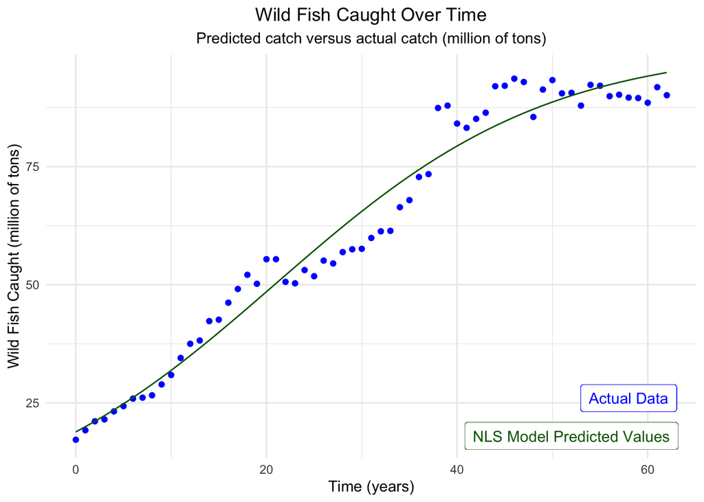

**Figure 3.0:** The actual amount of wild fish caught over time in million of tons is shown with the blue data points. The green line shows the predicted values for amount of wild fish caught based on the NonLinear Leat Squares model.

```r
#making the finalized data visualization
ggplot(data = fish_complete, aes(x = time, y =wild_catch))+
  geom_point(color = "blue")+
  geom_line(aes(x = time, y = fish_predict), color = "darkgreen")+
  theme_minimal()+
  labs(x = "Time (years)", y= "Wild Fish Caught (million of tons)", title = "Wild Fish Caught Over Time",
       subtitle = "Predicted catch versus actual catch (million of tons)") +
  theme(plot.title = element_text(hjust = 0.5),
        plot.subtitle = element_text(hjust = 0.5))+
  geom_label(
    label = "Actual Data",
    x = 58,
    y = 26,
    label.padding = unit(0.40, "lines"),
    label.size = 0.15,
    color = "blue"
  )+
  geom_label(
    label = "NLS Model Predicted Values",
    x = 52,
    y = 18,
    label.padding = unit(0.40, "lines"),
    label.size = 0.10,
    color = "darkgreen"
  )
```

Data Citation: Global wild fish catch and aquaculture production, compiled by Earth Policy Institute with 1950-2010 from U.N. Food and Agriculture Organization (FAO), Global Capture Production and Global Aquaculture Production, electronic databases, at www.fao.org/fishery/topic/16140/en.